# 760-G4

```python
import pandas as pd
import numpy as np

from sklearn.model_selection import train_test_split
from sklearn.preprocessing import StandardScaler
from sklearn.utils.class_weight import compute_class_weight
```

```python
df = pd.read_csv("diabetes_012_health_indicators_BRFSS2015.csv")
```

```python
df.shape
```

```
(253680, 22)
```

```python
df.head()
```

|  | Diabetes_012 | HighBP | HighChol | CholCheck | BMI | Smoker | Stroke | HeartDiseaseorAttack | PhysActivity | Fruits | ... | AnyHealthcare | NoDocbcCost | GenHlth | MentHlth | PhysHlth | DiffWalk | Sex | Age | Education | Income |
| --- | --- | --- | --- | --- | --- | --- | --- | --- | --- | --- | --- | --- | --- | --- | --- | --- | --- | --- | --- | --- | --- |
| 0 | 0.0 | 1.0 | 1.0 | 1.0 | 40.0 | 1.0 | 0.0 | 0.0 | 0.0 | 0.0 | ... | 1.0 | 0.0 | 5.0 | 18.0 | 15.0 | 1.0 | 0.0 | 9.0 | 4.0 | 3.0 |
| 1 | 0.0 | 0.0 | 0.0 | 0.0 | 25.0 | 1.0 | 0.0 | 0.0 | 1.0 | 0.0 | ... | 0.0 | 1.0 | 3.0 | 0.0 | 0.0 | 0.0 | 0.0 | 7.0 | 6.0 | 1.0 |
| 2 | 0.0 | 1.0 | 1.0 | 1.0 | 28.0 | 0.0 | 0.0 | 0.0 | 0.0 | 1.0 | ... | 1.0 | 1.0 | 5.0 | 30.0 | 30.0 | 1.0 | 0.0 | 9.0 | 4.0 | 8.0 |
| 3 | 0.0 | 1.0 | 0.0 | 1.0 | 27.0 | 0.0 | 0.0 | 0.0 | 1.0 | 1.0 | ... | 1.0 | 0.0 | 2.0 | 0.0 | 0.0 | 0.0 | 0.0 | 11.0 | 3.0 | 6.0 |
| 4 | 0.0 | 1.0 | 1.0 | 1.0 | 24.0 | 0.0 | 0.0 | 0.0 | 1.0 | 1.0 | ... | 1.0 | 0.0 | 2.0 | 3.0 | 0.0 | 0.0 | 0.0 | 11.0 | 5.0 | 4.0 |

5 rows × 22 columns

```python
df.info()
```

```
<class 'pandas.core.frame.DataFrame'>
RangeIndex: 253680 entries, 0 to 253679
Data columns (total 22 columns):
 #   Column                Non-Null Count   Dtype
---  ------                --------------   -----
 0   Diabetes_012          253680 non-null  float64
 1   HighBP                253680 non-null  float64
 2   HighChol              253680 non-null  float64
 3   CholCheck             253680 non-null  float64
 4   BMI                   253680 non-null  float64
 5   Smoker                253680 non-null  float64
 6   Stroke                253680 non-null  float64
 7   HeartDiseaseorAttack  253680 non-null  float64
 8   PhysActivity          253680 non-null  float64
 9   Fruits                253680 non-null  float64
 10  Veggies               253680 non-null  float64
 11  HvyAlcoholConsump     253680 non-null  float64
 12  AnyHealthcare         253680 non-null  float64
 13  NoDocbcCost           253680 non-null  float64
 14  GenHlth               253680 non-null  float64
 15  MentHlth              253680 non-null  float64
 16  PhysHlth              253680 non-null  float64
 17  DiffWalk              253680 non-null  float64
 18  Sex                   253680 non-null  float64
 19  Age                   253680 non-null  float64
 20  Education             253680 non-null  float64
 21  Income                253680 non-null  float64
dtypes: float64(22)
memory usage: 42.6 MB
```

```python
df["Diabetes_012"].value_counts()
```

```
Diabetes_012
0.0    213703
2.0     35346
1.0      4631
Name: count, dtype: int64
```

```python
df["Diabetes_012"].value_counts(normalize=True)
```

```
Diabetes_012
0.0    0.842412
2.0    0.139333
1.0    0.018255
Name: proportion, dtype: float64
```

The dataset shows class imbalance across the three categories.

```python
df.isnull().sum()
```

```
Diabetes_012            0
HighBP                  0
HighChol                0
CholCheck               0
BMI                     0
Smoker                  0
Stroke                  0
HeartDiseaseorAttack    0
PhysActivity            0
Fruits                  0
Veggies                 0
HvyAlcoholConsump       0
AnyHealthcare           0
NoDocbcCost             0
GenHlth                 0
MentHlth                0
PhysHlth                0
DiffWalk                0
Sex                     0
Age                     0
Education               0
Income                  0
dtype: int64
```

```python
df.duplicated().sum()
```

```
23899
```

```python
df = df.drop_duplicates()
```

```python
X = df.drop(columns=["Diabetes_012"])
y = df["Diabetes_012"]
```

```python
sensitive_features = ["Sex", "Age", "Income"]
```

```python
df["Sex"].value_counts()
df["Age"].value_counts().sort_index()
df["Income"].value_counts().sort_index()
```

```
Income
1.0     9792
2.0    11757
3.0    15922
4.0    19957
5.0    25345
6.0    35001
7.0    40189
8.0    71818
Name: count, dtype: int64
```

```python
pd.crosstab(df["Sex"], df["Diabetes_012"], normalize="index")
```

| Diabetes_012 Sex | 0.0 | 1.0 | 2.0 |
| --- | --- | --- | --- |
| 0.0 | 0.837421 | 0.020209 | 0.142370 |
| 1.0 | 0.813955 | 0.020064 | 0.165981 |

```python
pd.crosstab(df["Age"], df["Diabetes_012"], normalize="index")
```

| Diabetes_012 Age | 0.0 | 1.0 | 2.0 |
| --- | --- | --- | --- |
| 1.0 | 0.982039 | 0.003810 | 0.014151 |
| 2.0 | 0.972552 | 0.007640 | 0.019808 |
| 3.0 | 0.961496 | 0.007182 | 0.031322 |
| 4.0 | 0.937306 | 0.011607 | 0.051087 |
| 5.0 | 0.913737 | 0.011601 | 0.074662 |
| 6.0 | 0.881323 | 0.018036 | 0.100642 |
| 7.0 | 0.849179 | 0.018064 | 0.132757 |
| 8.0 | 0.824512 | 0.020146 | 0.155342 |
| 9.0 | 0.785344 | 0.023608 | 0.191048 |
| 10.0 | 0.753840 | 0.023896 | 0.222264 |
| 11.0 | 0.741799 | 0.027267 | 0.230933 |
| 12.0 | 0.751332 | 0.028907 | 0.219761 |
| 13.0 | 0.782787 | 0.026884 | 0.190329 |

```python
df.isnull().sum()
```

```
Diabetes_012            0
HighBP                  0
HighChol                0
CholCheck               0
BMI                     0
Smoker                  0
Stroke                  0
HeartDiseaseorAttack    0
PhysActivity            0
Fruits                  0
Veggies                 0
HvyAlcoholConsump       0
AnyHealthcare           0
NoDocbcCost             0
GenHlth                 0
MentHlth                0
PhysHlth                0
DiffWalk                0
Sex                     0
Age                     0
Education               0
Income                  0
dtype: int64
```

```python
df.duplicated().sum()
```

```
0
```

```python
X = df.drop(columns=["Diabetes_012"])
y = df["Diabetes_012"]
```

```python
from sklearn.model_selection import train_test_split

X_train, X_test, y_train, y_test = train_test_split(
    X,
    y,
    test_size=0.2,
    random_state=42,
    stratify=y
)
```

```python
from imblearn.over_sampling import SMOTE

smote = SMOTE(random_state=42)
X_train_smote, y_train_smote = smote.fit_resample(X_train, y_train)
```

```python
from imblearn.over_sampling import SMOTE

smote = SMOTE(random_state=42)
X_train_smote, y_train_smote = smote.fit_resample(X_train, y_train)

print("Before SMOTE:")
print(y_train.value_counts(normalize=True))

print("\nAfter SMOTE:")
print(y_train_smote.value_counts(normalize=True))
```

```
Before SMOTE:
Diabetes_012
0.0    0.827112
2.0    0.152744
1.0    0.020144
Name: proportion, dtype: float64

After SMOTE:
Diabetes_012
0.0    0.333333
2.0    0.333333
1.0    0.333333
Name: proportion, dtype: float64
```

```python
# SMOTE was applied only to the training set to reduce class imbalance.
# The test set was kept unchanged for fair evaluation.
```

# Baseline model

## Logistics Regression

```python
from sklearn.preprocessing import StandardScaler
from sklearn.linear_model import LogisticRegression
from sklearn.metrics import accuracy_score, f1_score, classification_report, confusion_matrix

# Step 1: scale features
scaler = StandardScaler()
X_train_smote_scaled = scaler.fit_transform(X_train_smote)
X_test_scaled = scaler.transform(X_test)

# Step 2: define model
lr = LogisticRegression(
    max_iter=1000,
    random_state=42,
    multi_class='multinomial'
)

# Step 3: train model
lr.fit(X_train_smote_scaled, y_train_smote)

# Step 4: predict on original test set
y_pred_lr = lr.predict(X_test_scaled)

# Step 5: evaluate
print("=== Logistic Regression Results ===")
print("Accuracy:", accuracy_score(y_test, y_pred_lr))
print("Macro-F1:", f1_score(y_test, y_pred_lr, average='macro'))
print("\nClassification Report:")
print(classification_report(y_test, y_pred_lr))
print("\nConfusion Matrix:")
print(confusion_matrix(y_test, y_pred_lr))
```

```
=== Logistic Regression Results ===
Accuracy: 0.6254107100115325
Macro-F1: 0.4230899079992955

Classification Report:
              precision    recall  f1-score   support

         0.0       0.94      0.64      0.76     38012
         1.0       0.03      0.31      0.06       926
         2.0       0.36      0.58      0.45      7019

    accuracy                           0.63     45957
   macro avg       0.45      0.51      0.42     45957
weighted avg       0.84      0.63      0.70     45957


Confusion Matrix:
[[24369  6853  6790]
 [  265   289   372]
 [ 1243  1692  4084]]
```

```python
lr_results = {
    "Model": "Logistic Regression",
    "Accuracy": accuracy_score(y_test, y_pred_lr),
    "Macro_F1": f1_score(y_test, y_pred_lr, average='macro')
}

print(lr_results)
```

```
{'Model': 'Logistic Regression', 'Accuracy': 0.6254107100115325, 'Macro_F1': 0.4230899079992955}
```

## Random Forest

```python
from sklearn.ensemble import RandomForestClassifier
from sklearn.metrics import accuracy_score, f1_score, classification_report, confusion_matrix

# Step 1: define model
rf = RandomForestClassifier(
    n_estimators=100,
    max_depth=5,
    random_state=42
)

# Step 2: train model
rf.fit(X_train_smote, y_train_smote)

# Step 3: predict on original test set
y_pred_rf = rf.predict(X_test)

# Step 4: evaluate
print("=== Random Forest Results ===")
print("Accuracy:", accuracy_score(y_test, y_pred_rf))
print("Macro-F1:", f1_score(y_test, y_pred_rf, average='macro'))
print("\nClassification Report:")
print(classification_report(y_test, y_pred_rf))
print("\nConfusion Matrix:")
print(confusion_matrix(y_test, y_pred_rf))
```

```
=== Random Forest Results ===
Accuracy: 0.7523989816567661
Macro-F1: 0.4451947191287882

Classification Report:
              precision    recall  f1-score   support

         0.0       0.91      0.80      0.85     38012
         1.0       0.04      0.04      0.04       926
         2.0       0.36      0.59      0.45      7019

    accuracy                           0.75     45957
   macro avg       0.43      0.48      0.45     45957
weighted avg       0.81      0.75      0.77     45957


Confusion Matrix:
[[30373   729  6910]
 [  507    33   386]
 [ 2669   178  4172]]
```

```python
rf_results = {
    "Model": "Random Forest",
    "Accuracy": accuracy_score(y_test, y_pred_rf),
    "Macro_F1": f1_score(y_test, y_pred_rf, average='macro')
}

print(rf_results)
```

```
{'Model': 'Random Forest', 'Accuracy': 0.7523989816567661, 'Macro_F1': 0.4451947191287882}
```

```python
import pandas as pd

comparison_df = pd.DataFrame([lr_results, rf_results])
comparison_df
```

|  | Model | Accuracy | Macro_F1 |
| --- | --- | --- | --- |
| 0 | Logistic Regression | 0.625411 | 0.423090 |
| 1 | Random Forest | 0.752399 | 0.445195 |

## XGBoost

```python
from xgboost import XGBClassifier
from sklearn.metrics import accuracy_score, f1_score, classification_report, confusion_matrix

# Step 1: define model
xgb = XGBClassifier(
    objective='multi:softmax',
    num_class=3,
    eval_metric='mlogloss',
    n_estimators=100,
    max_depth=3,
    learning_rate=0.1,
    n_jobs=-1,
    random_state=42
)

# Step 2: train model
xgb.fit(X_train_smote, y_train_smote)

# Step 3: predict on original test set
y_pred_xgb = xgb.predict(X_test)

# Step 4: evaluate
print("=== XGBoost Results ===")
print("Accuracy:", accuracy_score(y_test, y_pred_xgb))
print("Macro-F1:", f1_score(y_test, y_pred_xgb, average='macro'))
print("\nClassification Report:")
print(classification_report(y_test, y_pred_xgb))
print("\nConfusion Matrix:")
print(confusion_matrix(y_test, y_pred_xgb))
```

```
=== XGBoost Results ===
Accuracy: 0.8088648084078596
Macro-F1: 0.44603913494319175

Classification Report:
              precision    recall  f1-score   support

         0.0       0.89      0.89      0.89     38012
         1.0       0.00      0.00      0.00       926
         2.0       0.43      0.47      0.45      7019

    accuracy                           0.81     45957
   macro avg       0.44      0.45      0.45     45957
weighted avg       0.80      0.81      0.80     45957


Confusion Matrix:
[[33851     0  4161]
 [  659     0   267]
 [ 3697     0  3322]]
```

```python
xgb_results = {
    "Model": "XGBoost",
    "Accuracy": accuracy_score(y_test, y_pred_xgb),
    "Macro_F1": f1_score(y_test, y_pred_xgb, average='macro')
}

print(xgb_results)
```

```
{'Model': 'XGBoost', 'Accuracy': 0.8088648084078596, 'Macro_F1': 0.44603913494319175}
```

### comparison table

```python
comparison_df = pd.DataFrame([lr_results, rf_results, xgb_results])
comparison_df
```

|  | Model | Accuracy | Macro_F1 |
| --- | --- | --- | --- |
| 0 | Logistic Regression | 0.625411 | 0.423090 |
| 1 | Random Forest | 0.752399 | 0.445195 |
| 2 | XGBoost | 0.808865 | 0.446039 |

# Subgroup fairness evaluation

```python
sensitive_features = ["Sex", "Age", "Income"]
sensitive_test = X_test[sensitive_features].copy()
```

```python
fairness_df = sensitive_test.copy()
fairness_df["y_true"] = y_test.values
fairness_df["lr_pred"] = y_pred_lr
fairness_df["rf_pred"] = y_pred_rf
fairness_df["xgb_pred"] = y_pred_xgb

fairness_df.head()
```

|  | Sex | Age | Income | y_true | lr_pred | rf_pred | xgb_pred |
| --- | --- | --- | --- | --- | --- | --- | --- |
| 251778 | 1.0 | 9.0 | 1.0 | 2.0 | 2.0 | 2.0 | 2 |
| 147101 | 1.0 | 8.0 | 6.0 | 0.0 | 0.0 | 0.0 | 0 |
| 151531 | 1.0 | 9.0 | 7.0 | 0.0 | 2.0 | 0.0 | 0 |
| 129092 | 0.0 | 7.0 | 3.0 | 0.0 | 1.0 | 2.0 | 0 |
| 192671 | 0.0 | 9.0 | 7.0 | 2.0 | 1.0 | 0.0 | 0 |

### subgroup evaluation

```python
from sklearn.metrics import accuracy_score, f1_score

def evaluate_by_group(df, group_col, pred_col):
    results = []

    for group_value in sorted(df[group_col].unique()):
        subset = df[df[group_col] == group_value]

        acc = accuracy_score(subset["y_true"], subset[pred_col])
        macro_f1 = f1_score(subset["y_true"], subset[pred_col], average="macro")

        results.append({
            "GroupFeature": group_col,
            "GroupValue": group_value,
            "Model": pred_col,
            "N": len(subset),
            "Accuracy": acc,
            "Macro_F1": macro_f1
        })

    return pd.DataFrame(results)
```

```python
lr_sex = evaluate_by_group(fairness_df, "Sex", "lr_pred")
lr_age = evaluate_by_group(fairness_df, "Age", "lr_pred")
lr_income = evaluate_by_group(fairness_df, "Income", "lr_pred")

pd.concat([lr_sex, lr_age, lr_income], ignore_index=True)
```

|  | GroupFeature | GroupValue | Model | N | Accuracy | Macro_F1 |
| --- | --- | --- | --- | --- | --- | --- |
| 0 | Sex | 0.0 | lr_pred | 25657 | 0.635616 | 0.426824 |
| 1 | Sex | 1.0 | lr_pred | 20300 | 0.612512 | 0.416880 |
| 2 | Age | 1.0 | lr_pred | 1071 | 0.976657 | 0.413031 |
| 3 | Age | 2.0 | lr_pred | 1432 | 0.939944 | 0.383926 |
| 4 | Age | 3.0 | lr_pred | 2036 | 0.905697 | 0.400783 |
| 5 | Age | 4.0 | lr_pred | 2473 | 0.862111 | 0.429402 |
| 6 | Age | 5.0 | lr_pred | 2854 | 0.826559 | 0.429786 |
| 7 | Age | 6.0 | lr_pred | 3417 | 0.761487 | 0.442951 |
| 8 | Age | 7.0 | lr_pred | 4600 | 0.696957 | 0.433174 |
| 9 | Age | 8.0 | lr_pred | 5476 | 0.635866 | 0.425631 |
| 10 | Age | 9.0 | lr_pred | 5996 | 0.573215 | 0.414854 |
| 11 | Age | 10.0 | lr_pred | 5850 | 0.518803 | 0.398939 |
| 12 | Age | 11.0 | lr_pred | 4396 | 0.452912 | 0.365693 |
| 13 | Age | 12.0 | lr_pred | 3028 | 0.397952 | 0.333316 |
| 14 | Age | 13.0 | lr_pred | 3328 | 0.317608 | 0.275211 |
| 15 | Income | 1.0 | lr_pred | 1957 | 0.499234 | 0.396576 |
| 16 | Income | 2.0 | lr_pred | 2269 | 0.457470 | 0.376939 |
| 17 | Income | 3.0 | lr_pred | 3182 | 0.487744 | 0.392410 |
| 18 | Income | 4.0 | lr_pred | 3983 | 0.516194 | 0.393773 |
| 19 | Income | 5.0 | lr_pred | 5096 | 0.543564 | 0.396368 |
| 20 | Income | 6.0 | lr_pred | 6971 | 0.611247 | 0.417987 |
| 21 | Income | 7.0 | lr_pred | 8055 | 0.654749 | 0.414804 |
| 22 | Income | 8.0 | lr_pred | 14444 | 0.748685 | 0.429289 |

```python
rf_sex = evaluate_by_group(fairness_df, "Sex", "rf_pred")
rf_age = evaluate_by_group(fairness_df, "Age", "rf_pred")
rf_income = evaluate_by_group(fairness_df, "Income", "rf_pred")

pd.concat([rf_sex, rf_age, rf_income], ignore_index=True)
```

|  | GroupFeature | GroupValue | Model | N | Accuracy | Macro_F1 |
| --- | --- | --- | --- | --- | --- | --- |
| 0 | Sex | 0.0 | rf_pred | 25657 | 0.765600 | 0.448428 |
| 1 | Sex | 1.0 | rf_pred | 20300 | 0.735714 | 0.440938 |
| 2 | Age | 1.0 | rf_pred | 1071 | 0.978525 | 0.381146 |
| 3 | Age | 2.0 | rf_pred | 1432 | 0.961592 | 0.374407 |
| 4 | Age | 3.0 | rf_pred | 2036 | 0.938605 | 0.390910 |
| 5 | Age | 4.0 | rf_pred | 2473 | 0.909017 | 0.411881 |
| 6 | Age | 5.0 | rf_pred | 2854 | 0.887176 | 0.421186 |
| 7 | Age | 6.0 | rf_pred | 3417 | 0.847820 | 0.433319 |
| 8 | Age | 7.0 | rf_pred | 4600 | 0.799565 | 0.440324 |
| 9 | Age | 8.0 | rf_pred | 5476 | 0.754931 | 0.445223 |
| 10 | Age | 9.0 | rf_pred | 5996 | 0.700967 | 0.447844 |
| 11 | Age | 10.0 | rf_pred | 5850 | 0.667350 | 0.433024 |
| 12 | Age | 11.0 | rf_pred | 4396 | 0.632848 | 0.424593 |
| 13 | Age | 12.0 | rf_pred | 3028 | 0.615918 | 0.403294 |
| 14 | Age | 13.0 | rf_pred | 3328 | 0.600661 | 0.379773 |
| 15 | Income | 1.0 | rf_pred | 1957 | 0.677057 | 0.433484 |
| 16 | Income | 2.0 | rf_pred | 2269 | 0.631996 | 0.427943 |
| 17 | Income | 3.0 | rf_pred | 3182 | 0.684475 | 0.452263 |
| 18 | Income | 4.0 | rf_pred | 3983 | 0.690685 | 0.423811 |
| 19 | Income | 5.0 | rf_pred | 5096 | 0.714678 | 0.438465 |
| 20 | Income | 6.0 | rf_pred | 6971 | 0.734041 | 0.437550 |
| 21 | Income | 7.0 | rf_pred | 8055 | 0.756673 | 0.426896 |
| 22 | Income | 8.0 | rf_pred | 14444 | 0.833287 | 0.440660 |

```python
xgb_sex = evaluate_by_group(fairness_df, "Sex", "xgb_pred")
xgb_age = evaluate_by_group(fairness_df, "Age", "xgb_pred")
xgb_income = evaluate_by_group(fairness_df, "Income", "xgb_pred")

pd.concat([xgb_sex, xgb_age, xgb_income], ignore_index=True)
```

|  | GroupFeature | GroupValue | Model | N | Accuracy | Macro_F1 |
| --- | --- | --- | --- | --- | --- | --- |
| 0 | Sex | 0.0 | xgb_pred | 25657 | 0.825311 | 0.449379 |
| 1 | Sex | 1.0 | xgb_pred | 20300 | 0.788079 | 0.441485 |
| 2 | Age | 1.0 | xgb_pred | 1071 | 0.985994 | 0.375425 |
| 3 | Age | 2.0 | xgb_pred | 1432 | 0.976257 | 0.372334 |
| 4 | Age | 3.0 | xgb_pred | 2036 | 0.956287 | 0.366109 |
| 5 | Age | 4.0 | xgb_pred | 2473 | 0.934088 | 0.406646 |
| 6 | Age | 5.0 | xgb_pred | 2854 | 0.915907 | 0.415538 |
| 7 | Age | 6.0 | xgb_pred | 3417 | 0.868891 | 0.418115 |
| 8 | Age | 7.0 | xgb_pred | 4600 | 0.840000 | 0.442791 |
| 9 | Age | 8.0 | xgb_pred | 5476 | 0.805332 | 0.442875 |
| 10 | Age | 9.0 | xgb_pred | 5996 | 0.774516 | 0.451873 |
| 11 | Age | 10.0 | xgb_pred | 5850 | 0.744786 | 0.448503 |
| 12 | Age | 11.0 | xgb_pred | 4396 | 0.712011 | 0.427969 |
| 13 | Age | 12.0 | xgb_pred | 3028 | 0.714003 | 0.426050 |
| 14 | Age | 13.0 | xgb_pred | 3328 | 0.694712 | 0.390673 |
| 15 | Income | 1.0 | xgb_pred | 1957 | 0.729688 | 0.446725 |
| 16 | Income | 2.0 | xgb_pred | 2269 | 0.699427 | 0.438857 |
| 17 | Income | 3.0 | xgb_pred | 3182 | 0.743558 | 0.452601 |
| 18 | Income | 4.0 | xgb_pred | 3983 | 0.758725 | 0.441322 |
| 19 | Income | 5.0 | xgb_pred | 5096 | 0.781790 | 0.444508 |
| 20 | Income | 6.0 | xgb_pred | 6971 | 0.797303 | 0.436649 |
| 21 | Income | 7.0 | xgb_pred | 8055 | 0.821353 | 0.432546 |
| 22 | Income | 8.0 | xgb_pred | 14444 | 0.873165 | 0.433553 |

```python
fairness_results = pd.concat(
    [lr_sex, lr_age, lr_income,
     rf_sex, rf_age, rf_income,
     xgb_sex, xgb_age, xgb_income],
    ignore_index=True
)

fairness_results = fairness_results.round(3)
fairness_results
```

|  | GroupFeature | GroupValue | Model | N | Accuracy | Macro_F1 |
| --- | --- | --- | --- | --- | --- | --- |
| 0 | Sex | 0.0 | lr_pred | 25657 | 0.636 | 0.427 |
| 1 | Sex | 1.0 | lr_pred | 20300 | 0.613 | 0.417 |
| 2 | Age | 1.0 | lr_pred | 1071 | 0.977 | 0.413 |
| 3 | Age | 2.0 | lr_pred | 1432 | 0.940 | 0.384 |
| 4 | Age | 3.0 | lr_pred | 2036 | 0.906 | 0.401 |
| ... | ... | ... | ... | ... | ... | ... |
| 64 | Income | 4.0 | xgb_pred | 3983 | 0.759 | 0.441 |
| 65 | Income | 5.0 | xgb_pred | 5096 | 0.782 | 0.445 |
| 66 | Income | 6.0 | xgb_pred | 6971 | 0.797 | 0.437 |
| 67 | Income | 7.0 | xgb_pred | 8055 | 0.821 | 0.433 |
| 68 | Income | 8.0 | xgb_pred | 14444 | 0.873 | 0.434 |

69 rows × 6 columns

```python
gap_summary = fairness_results.groupby(["GroupFeature", "Model"]).agg(
    max_macro_f1=("Macro_F1", "max"),
    min_macro_f1=("Macro_F1", "min")
).reset_index()

gap_summary["gap"] = gap_summary["max_macro_f1"] - gap_summary["min_macro_f1"]
gap_summary = gap_summary.round(3)
gap_summary
```

|  | GroupFeature | Model | max_macro_f1 | min_macro_f1 | gap |
| --- | --- | --- | --- | --- | --- |
| 0 | Age | lr_pred | 0.443 | 0.275 | 0.168 |
| 1 | Age | rf_pred | 0.448 | 0.374 | 0.074 |
| 2 | Age | xgb_pred | 0.452 | 0.366 | 0.086 |
| 3 | Income | lr_pred | 0.429 | 0.377 | 0.052 |
| 4 | Income | rf_pred | 0.452 | 0.424 | 0.028 |
| 5 | Income | xgb_pred | 0.453 | 0.433 | 0.020 |
| 6 | Sex | lr_pred | 0.427 | 0.417 | 0.010 |
| 7 | Sex | rf_pred | 0.448 | 0.441 | 0.007 |
| 8 | Sex | xgb_pred | 0.449 | 0.441 | 0.008 |

```python
gap_summary["FairnessSummary"] = gap_summary["gap"].apply(
    lambda x: "Small gap" if x < 0.03 else ("Moderate gap" if x < 0.08 else "Large gap")
)

gap_summary
```

|  | GroupFeature | Model | max_macro_f1 | min_macro_f1 | gap | FairnessSummary |
| --- | --- | --- | --- | --- | --- | --- |
| 0 | Age | lr_pred | 0.443 | 0.275 | 0.168 | Large gap |
| 1 | Age | rf_pred | 0.448 | 0.374 | 0.074 | Moderate gap |
| 2 | Age | xgb_pred | 0.452 | 0.366 | 0.086 | Large gap |
| 3 | Income | lr_pred | 0.429 | 0.377 | 0.052 | Moderate gap |
| 4 | Income | rf_pred | 0.452 | 0.424 | 0.028 | Small gap |
| 5 | Income | xgb_pred | 0.453 | 0.433 | 0.020 | Small gap |
| 6 | Sex | lr_pred | 0.427 | 0.417 | 0.010 | Small gap |
| 7 | Sex | rf_pred | 0.448 | 0.441 | 0.007 | Small gap |
| 8 | Sex | xgb_pred | 0.449 | 0.441 | 0.008 | Small gap |

The subgroup fairness analysis shows that model performance is relatively consistent across sex groups, but less consistent across age and income groups. Among the three sensitive features, age has the largest Macro-F1 gap across all models, indicating the strongest subgroup disparity. Logistic Regression is most sensitive to age-related differences, while Random Forest provides a more balanced trade-off between predictive performance and subgroup consistency. Although XGBoost achieves the strongest overall performance, it does not eliminate fairness disparities, especially across age groups.

# Subgroup Fairness Evaluation

```python
# clean model names
model_name_map = {
    "lr_pred": "Logistic Regression",
    "rf_pred": "Random Forest",
    "xgb_pred": "XGBoost"
}

gap_summary_clean = gap_summary.copy()
gap_summary_clean["Model"] = gap_summary_clean["Model"].map(model_name_map)

gap_summary_clean = gap_summary_clean.rename(columns={
    "GroupFeature": "SensitiveFeature",
    "max_macro_f1": "BestGroup_MacroF1",
    "min_macro_f1": "WorstGroup_MacroF1",
    "gap": "MacroF1_Gap"
})

gap_summary_clean = gap_summary_clean.round(3)
gap_summary_clean
```

|  | SensitiveFeature | Model | BestGroup_MacroF1 | WorstGroup_MacroF1 | MacroF1_Gap | FairnessSummary |
| --- | --- | --- | --- | --- | --- | --- |
| 0 | Age | Logistic Regression | 0.443 | 0.275 | 0.168 | Large gap |
| 1 | Age | Random Forest | 0.448 | 0.374 | 0.074 | Moderate gap |
| 2 | Age | XGBoost | 0.452 | 0.366 | 0.086 | Large gap |
| 3 | Income | Logistic Regression | 0.429 | 0.377 | 0.052 | Moderate gap |
| 4 | Income | Random Forest | 0.452 | 0.424 | 0.028 | Small gap |
| 5 | Income | XGBoost | 0.453 | 0.433 | 0.020 | Small gap |
| 6 | Sex | Logistic Regression | 0.427 | 0.417 | 0.010 | Small gap |
| 7 | Sex | Random Forest | 0.448 | 0.441 | 0.007 | Small gap |
| 8 | Sex | XGBoost | 0.449 | 0.441 | 0.008 | Small gap |

```python
fairness_pivot = gap_summary_clean.pivot(
    index="SensitiveFeature",
    columns="Model",
    values="MacroF1_Gap"
).round(3)

fairness_pivot
```

| Model SensitiveFeature | Logistic Regression | Random Forest | XGBoost |
| --- | --- | --- | --- |
| Age | 0.168 | 0.074 | 0.086 |
| Income | 0.052 | 0.028 | 0.020 |
| Sex | 0.010 | 0.007 | 0.008 |

```python
comparison_df.round(3).to_csv("model_comparison_results.csv", index=False)
gap_summary_clean.to_csv("fairness_gap_summary.csv", index=False)
fairness_pivot.to_csv("fairness_gap_pivot.csv")
```

# Explainability

```python
import numpy as np
import pandas as pd

shap_array = np.array(shap_values_rf)
print("SHAP array shape:", shap_array.shape)

# Case 1: binary / multiclass returned as list-like converted to 3D
if shap_array.ndim == 3:
    # average over samples and classes
    shap_abs_mean = np.abs(shap_array).mean(axis=(0, 2))

# Case 2: returned as 2D (samples, features)
elif shap_array.ndim == 2:
    shap_abs_mean = np.abs(shap_array).mean(axis=0)

# Case 3: other format
else:
    raise ValueError(f"Unexpected SHAP shape: {shap_array.shape}")

rf_shap_importance = pd.DataFrame({
    "Feature": X_shap.columns,
    "MeanAbsSHAP": shap_abs_mean
}).sort_values("MeanAbsSHAP", ascending=False)

rf_shap_importance.head(10)
```

```
SHAP array shape: (1000, 21, 3)
```

|  | Feature | MeanAbsSHAP |
| --- | --- | --- |
| 0 | HighBP | 0.073459 |
| 1 | HighChol | 0.051692 |
| 13 | GenHlth | 0.041044 |
| 18 | Age | 0.019192 |
| 3 | BMI | 0.015341 |
| 16 | DiffWalk | 0.013968 |
| 17 | Sex | 0.007378 |
| 7 | PhysActivity | 0.006539 |
| 6 | HeartDiseaseorAttack | 0.006096 |
| 20 | Income | 0.004951 |

In the Random Forest model, the most influential features were HighBP, HighChol, and GenHlth, followed by Age and BMI. This suggests that the model relies strongly on clinically plausible health indicators rather than arbitrary variables.

Age is not only an important predictive feature, but also the subgroup dimension associated with the largest performance disparity.

Age appears in both analyses: it is one of the most important predictive features in SHAP, and it is also the subgroup attribute with the largest Macro-F1 gap. This suggests that age plays a central role in both model prediction and subgroup disparity.

Sex and Income also appeared in the top 10 features, although their average contribution was smaller than major health-related variables.

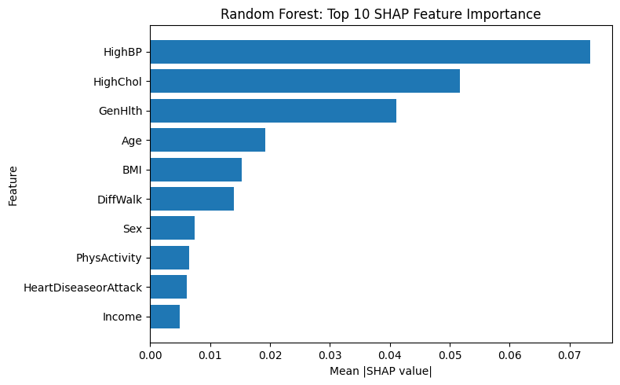

```python
import matplotlib.pyplot as plt

top10_rf = rf_shap_importance.head(10)

plt.figure(figsize=(8, 5))
plt.barh(top10_rf["Feature"][::-1], top10_rf["MeanAbsSHAP"][::-1])
plt.xlabel("Mean |SHAP value|")
plt.ylabel("Feature")
plt.title("Random Forest: Top 10 SHAP Feature Importance")
plt.tight_layout()
plt.show()
```

```python
rf_shap_importance.to_csv("rf_shap_importance.csv", index=False)
```

Current findings:

1. XGBoost achieved the strongest overall accuracy, while Random Forest provided a strong balance between predictive performance and subgroup consistency.
2. Sex-related subgroup gaps were small, whereas age-related disparities were the largest across models.
3. SHAP analysis showed that Random Forest relied mainly on clinically plausible variables such as HighBP, HighChol, GenHlth, Age, and BMI.
4. Age appeared in both fairness and explainability analyses, suggesting that it is central to both prediction quality and subgroup disparity.